# Stock Analysis and Forecasting

## Chapter V: Initial Data Analysis

As part of our analysis of the multiple time series, we will plot each stock without altering scale. W will be leveraging more vibrant colors in order to make sure the graph is distinguishable even for people with severe color deficiency.

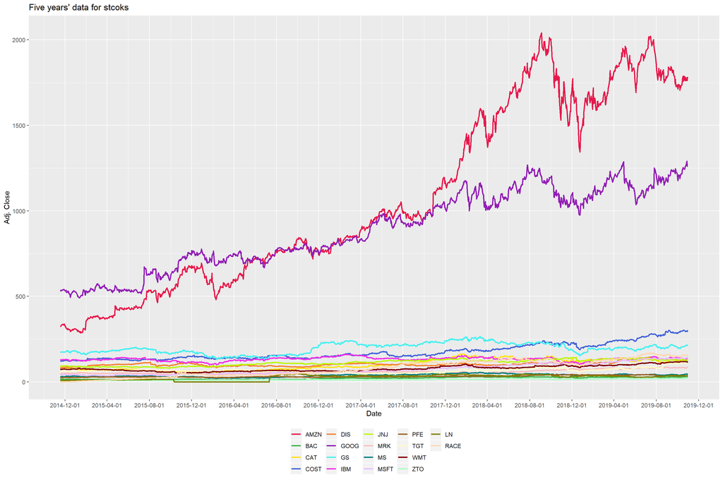

```r
meltdf <- melt(df,id="Date")

palette <- c('#e6194b', '#3cb44b', '#ffe119', '#4363d8', '#f58231', '#911eb4', '#46f0f0', '#f032e6', '#bcf60c', '#fabebe', '#008080', '#e6beff', '#9a6324', '#fffac8', '#800000', '#aaffc3', '#808000', '#ffd8b1', '#000075', '#808080') #18 distinct colors to represent different stocks

ggplot(meltdf, aes(Date, y=value,colour=variable,group=variable)) +
  geom_line(size=1) +
  labs(title="Five years' data for stcoks", x="Date", y="Adj. Close") +
  theme(legend.position="bottom") +
  theme(legend.title=element_blank()) +
  scale_x_date(breaks = "4 month") +
  scale_color_manual(values=palette)
```

Plot the scaled version:

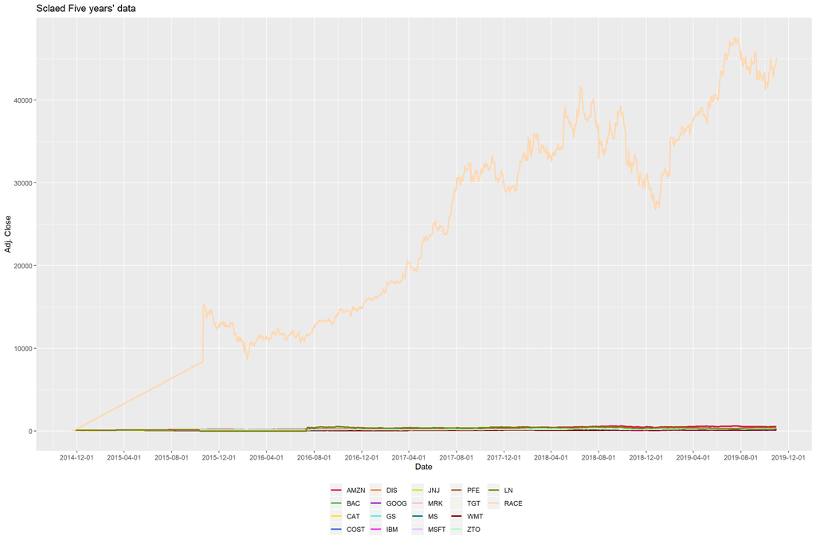

```r
dfa <- lapply(select(df, -Date), function(x) 100*x/x[1])
dfa <- cbind(Date = df$Date, as.data.frame(dfa))
dfam <- melt(dfa, id="Date", variable.name="share",value.name="price")

ggplot(dfam, aes(Date, y=price, colour=share, group=share)) +
  geom_line(size=1) +
  labs(title="Sclaed Five years' data", x="Date", y="Adj. Close") +
  theme(legend.position="bottom") +
  theme(legend.title=element_blank()) +
  scale_x_date(breaks = "4 month")+
  scale_color_manual(values=palette)
```

- After scaling such that all stocks start at the same price, the plot focuses on RACE(Ferrari) which performed very well, not allowing us to visualize the remainder of the stocks. We choose to exclude RACE(Ferrari) as well in order to make a better comparison between the rest of the stocks.

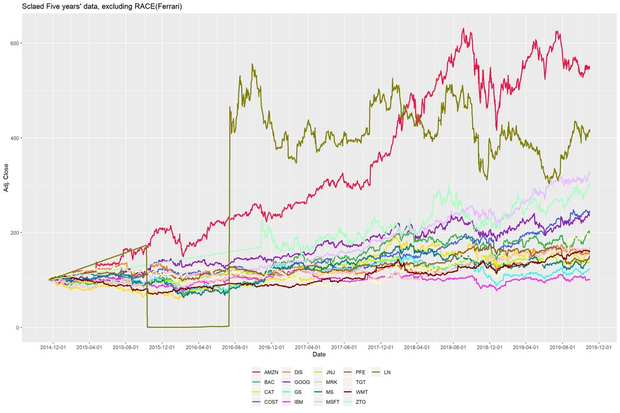

```r
dfa <- lapply(select(df, -Date), function(x) 100*x/x[1])
dfa <- cbind(Date = df$Date, as.data.frame(dfa))
dfam <- melt(dfa, id="Date", variable.name="share",value.name="price")
dfam_scaled <- subset(dfam,share!="RACE")

ggplot(dfam_scaled, aes(Date, y=price, colour=share, group=share)) +
  geom_line(size=1) +
  labs(title="Sclaed Five years' data, excluding RACE(Ferrari)", x="Date", y="Adj. Close") +
  theme(legend.position="bottom") +
  theme(legend.title=element_blank()) +
  scale_x_date(breaks = "4 month")+
  scale_color_manual(values=palette[-18])
```

From the scaled graph, we observe that AMZN and LN are the best performers and don’t seem to be affected too much by the scaling. As we predicted several values for Line (LN), we observe these values very clearly on the graph as they do not elegantly match the existing data. Also, we clearly observe the period when Line was not trading as the price is $0.

Next we will examine the normality of the stock price data as we need to have approximate normality in order to run our regression based factor models.

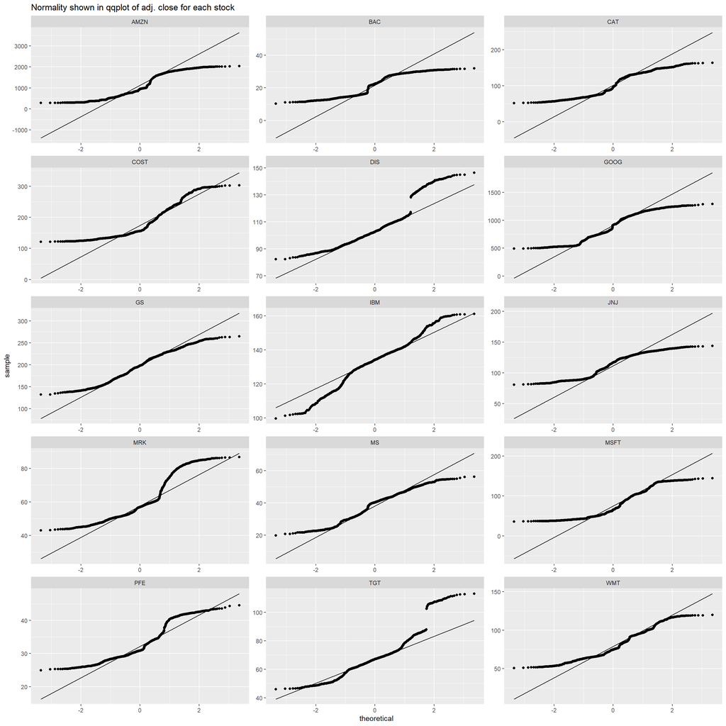

```r
gather(df[,2:19], condition, measurement, AMZN:WMT, factor_key = TRUE) %>%
  ggplot(aes(sample = measurement)) +
  facet_wrap(~ condition, scales = "free", nrow=6) +
  stat_qq() +
  stat_qq_line() +
  labs(title="Normality shown in qqplot of adj. close for each stock ")
```

Looking at the QQ Plots on the raw price data, we observe that many of our candidates do not follow a normal distribution. We will perform further investigations and apply transformations as necessary in order to reach approximate normality.

Next, we will compute the return for each stock as well as well as the Portfolio return and apply the natural logarithm transformation. As stock returns are said to follow a log-normal distribution, we expect that by taking the log of the return to obtain approximately normal data.

```r
#calculate weighted return

return <- (df$AMZN - lag(df$AMZN, default = df$AMZN[1]))/lag(df$AMZN)
return <- data.frame(return)


df2 <- df[c(3:19)]
var <- c(1:17)
for (i in var){
company <- df2[,i]
return_i <- (company - lag(company, default = company[1]))/lag(company)
#return_i <- log(company/lag(company, default = company[1]))

data.frame(return_i)
return <- cbind(return, return_i)
}


weight = 1/18
tret <- rowSums(return*weight)
tret <- data.frame(tret)

log_return <- log(return)
```

Normality of return:

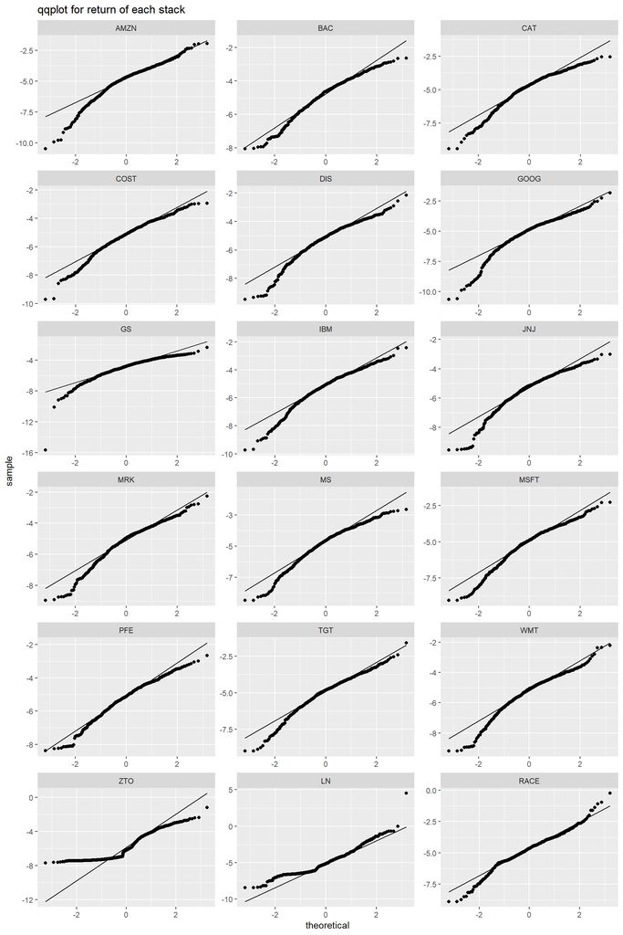

```r
colnames(log_return) <- c('AMZN',   'BAC',  'CAT',  'COST', 'DIS',  'GOOG', 'GS',   'IBM',  'JNJ',  'MRK',  'MS',   'MSFT', 'PFE',  'TGT',  'WMT','ZTO', 'LN', 'RACE')

#return <- log(return)

gather(log_return[-1,], condition, measurement, AMZN:RACE, factor_key = TRUE) %>%
  ggplot(aes(sample = measurement)) +
  facet_wrap(~ condition, scales = "free", nrow=6) +
  stat_qq() +
  stat_qq_line() +
  labs(title="qqplot for return of each stack")
```

After the transformations the returns seem approximately normal. We do observe deviations especially in the left tails (the so called fat tail phenomenon).

Also, we can observe that the data points gather at the bottom of the graph for LN. This is happening because there is an outlier with an extremely large value.

In conclusion, we can continue with running our factor models as we conclude our initial data analysis and transformation.

## Chapter VI: Factor Models (CAPM, Fama French, Momentum)

As part of our analysis we will compare the daily returns of our portfolio against various factors. The first factor model that we will analyse is the CAPM model. The CAPM model is very simplistic as it is a simple linear equation in which the market factor (which represents the performance of the general market) is regressed against our portfolio return. The constant of the equation will signify the value that is being added as part of our stock selection skills (also known as alpha) and will tell us how much return is attributed to them.

```r
fa <- read_csv("fama.csv")

weight2 = 1/16
tret2 <- rowSums(return[,1:16]*weight)
tret2 <- data.frame(tret2)

factormodel <- cbind(fa, tret2)
factormodel <- factormodel[-1,]
#factormodel <- factormodel[2:nrow(factormodel),]

capm <- lm(tret2 ~ MKT, data = factormodel )
summary(capm)
```

```
##
## Call:
## lm(formula = tret2 ~ MKT, data = factormodel)
##
## Residuals:
##        Min         1Q     Median         3Q        Max
## -0.0122144 -0.0016564 -0.0000967  0.0015650  0.0196875
##
## Coefficients:
##              Estimate Std. Error t value Pr(>|t|)
## (Intercept) 2.170e-04  7.585e-05   2.861  0.00429 **
## MKT         8.572e-03  8.654e-05  99.058  < 2e-16 ***
## ---
## Signif. codes:  0 '***' 0.001 '**' 0.01 '*' 0.05 '.' 0.1 ' ' 1
##
## Residual standard error: 0.002676 on 1245 degrees of freedom
## Multiple R-squared:  0.8874, Adjusted R-squared:  0.8873
## F-statistic:  9812 on 1 and 1245 DF,  p-value: < 2.2e-16
```

```r
PortfolioRet <- prod(tret2[-1,]+1)

cat("\nPortfolio returns can be predicted using the below regression formula under the CAPM model: /n Portfolio Return (CAPM) = ",capm$coefficients[1]," + ", capm$coefficients[2]," * Market Return")
```

```
##
## Portfolio returns can be predicted using the below regression formula under the CAPM model: /n Portfolio Return (CAPM) =  0.0002170394  +  0.008572172  * Market Return
```

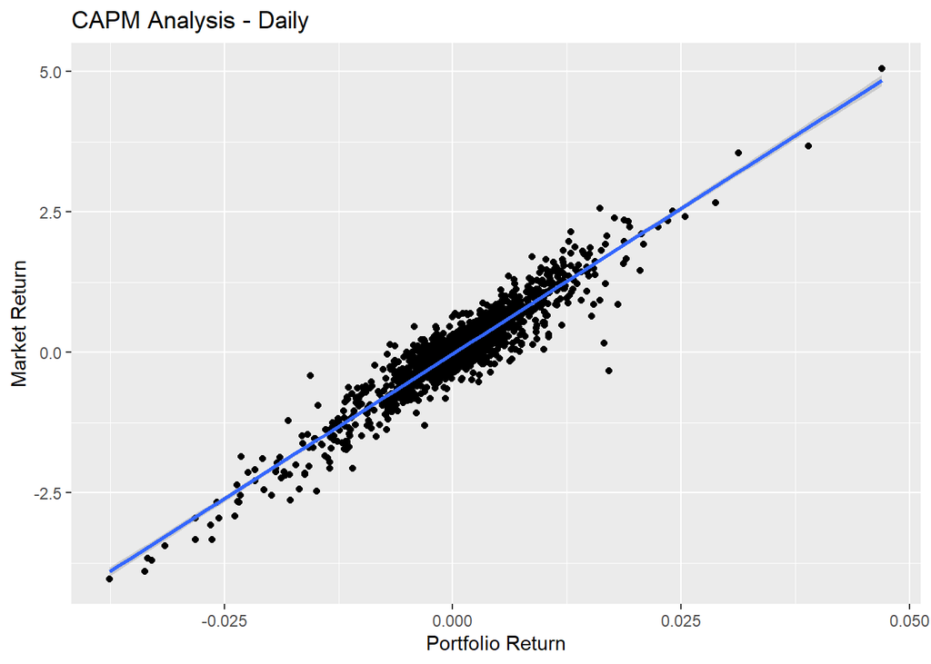

```r
ggplot(factormodel, aes(tret2,MKT))+ geom_point() + labs(title = "CAPM Analysis - Daily") + labs(x="Portfolio Return", y="Market Return") + geom_smooth(method='lm', formula= y~x)
```

The CAPM model yields a coefficient of determination of 0.88 (As expected, the adjusted R^2 is almost identical given that this is a simple linear regression) signaling most of the data is explained by the market factor. This is expected as we have a well diversified portfolio which means that as we keep adding more and more stocks with different return paths we will get closer and closer to the market. Looking at the intercept, we observe that 2 basis points in excess return above the market return are attributed to our stock selection capabilities on a daily basis. The graph also corroborates our findings as we can see a clear linear relationship between our portfolio returns and the market factor.

```r
famafrench <- lm(tret2 ~ MKT + SMB + HML, data = factormodel )
summary(famafrench)
```

```
##
## Call:
## lm(formula = tret2 ~ MKT + SMB + HML, data = factormodel)
##
## Residuals:
##        Min         1Q     Median         3Q        Max
## -0.0139707 -0.0015210 -0.0000235  0.0014549  0.0181643
##
## Coefficients:
##               Estimate Std. Error t value Pr(>|t|)
## (Intercept)  2.145e-04  7.306e-05   2.937  0.00338 **
## MKT          8.713e-03  8.447e-05 103.152  < 2e-16 ***
## SMB         -1.232e-03  1.461e-04  -8.433  < 2e-16 ***
## HML          6.486e-04  1.332e-04   4.870 1.26e-06 ***
## ---
## Signif. codes:  0 '***' 0.001 '**' 0.01 '*' 0.05 '.' 0.1 ' ' 1
##
## Residual standard error: 0.002576 on 1243 degrees of freedom
## Multiple R-squared:  0.8959, Adjusted R-squared:  0.8956
## F-statistic:  3564 on 3 and 1243 DF,  p-value: < 2.2e-16
```

```r
cat("\nPortfolio returns can be predicted using the below regression formula under the Fama French model: /nPortfolio Return (Fama French) = ",famafrench$coefficients[1]," + ", famafrench$coefficients[2]," * Market Return"," + ", famafrench$coefficients[3]," * Size Return"," + ", famafrench$coefficients[4]," * Value Return")
```

```
##
## Portfolio returns can be predicted using the below regression formula under the Fama French model: /nPortfolio Return (Fama French) =  0.0002145393  +  0.008713093  * Market Return  +  -0.001232283  * Size Return  +  0.0006486313  * Value Return
```

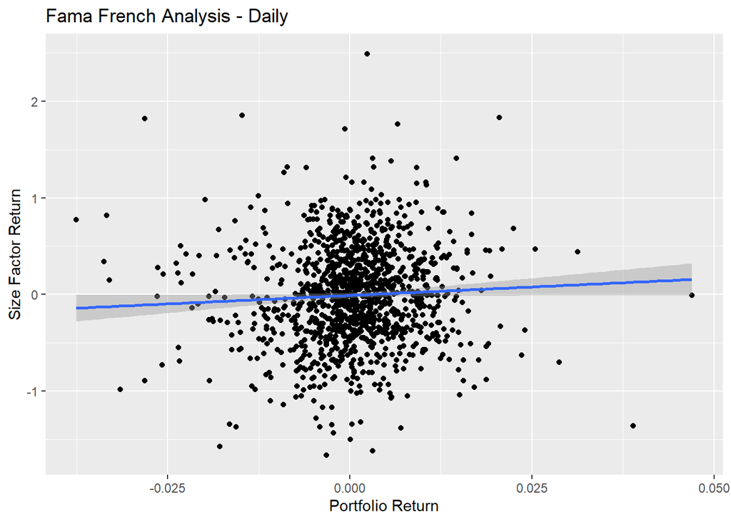

```r
ggplot(factormodel, aes(tret2,SMB))+ geom_point() + labs(title = "Fama French Analysis - Daily") + labs(x="Portfolio Return", y="Size Factor Return") + geom_smooth(method='lm', formula= y~x)
```

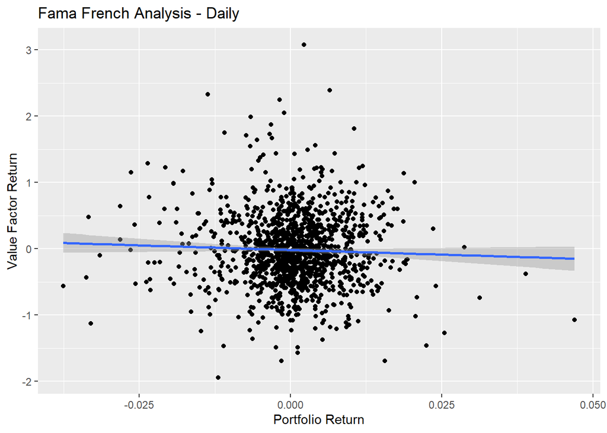

```r
ggplot(factormodel, aes(tret2,HML))+ geom_point() + labs(title = "Fama French Analysis - Daily") + labs(x="Portfolio Return", y="Value Factor Return") + geom_smooth(method='lm', formula= y~x)
```

In order to build the Fama French model, we are adding the size and value factors to our simple linear regression. Size represents the value add (increase in return) that is observed in smaller companies comapared to larger companies, while value represents stocks that are inexpensive compared to their fundamentals (Ex: PE ratio). Looking at our multi linear regression, we observe an increase in both the coefficienct of determination: 0.8959 and adjusted R^2: 0.8956 (On a side note, the adjusted R^2 takes into account the number of variables in the model when performing the regression). As such we can conclude that the Fama French Model is marginally better compared to the CAPM model. Looking at the scatterplots between our return and the size and value factors, we observe a slight positive linear relationship with the size factor and a slight negative linear relationship with the value factor. Overall, these trends seem insignificant compared to the Market factor.

```r
momentum <- lm(tret2 ~ MKT + SMB + HML + MOM, data = factormodel )
summary(momentum)
```

```
##
## Call:
## lm(formula = tret2 ~ MKT + SMB + HML + MOM, data = factormodel)
##
## Residuals:
##        Min         1Q     Median         3Q        Max
## -0.0138793 -0.0015192 -0.0000062  0.0014476  0.0182027
##
## Coefficients:
##               Estimate Std. Error t value Pr(>|t|)
## (Intercept)  2.113e-04  7.288e-05   2.899  0.00381 **
## MKT          8.743e-03  8.498e-05 102.885  < 2e-16 ***
## SMB         -1.135e-03  1.502e-04  -7.559 7.88e-14 ***
## HML          8.499e-04  1.524e-04   5.578 2.99e-08 ***
## MOM          2.918e-04  1.082e-04   2.697  0.00708 **
## ---
## Signif. codes:  0 '***' 0.001 '**' 0.01 '*' 0.05 '.' 0.1 ' ' 1
##
## Residual standard error: 0.002569 on 1242 degrees of freedom
## Multiple R-squared:  0.8965, Adjusted R-squared:  0.8961
## F-statistic:  2688 on 4 and 1242 DF,  p-value: < 2.2e-16
```

```r
cat("\nPortfolio returns can be predicted using the below regression formula under the Momentum model: /nPortfolio Return (Momentum) = ",momentum$coefficients[1]," + ", momentum$coefficients[2]," * Market Return"," + ", momentum$coefficients[3]," * Size Return"," + ", momentum$coefficients[4]," * Value Return"," + ", momentum$coefficients[5]," * Momentum Return")
```

```
##
## Portfolio returns can be predicted using the below regression formula under the Momentum model: /nPortfolio Return (Momentum) =  0.0002112558  +  0.008742896  * Market Return  +  -0.00113497  * Size Return  +  0.0008498797  * Value Return  +  0.0002918156  * Momentum Return
```

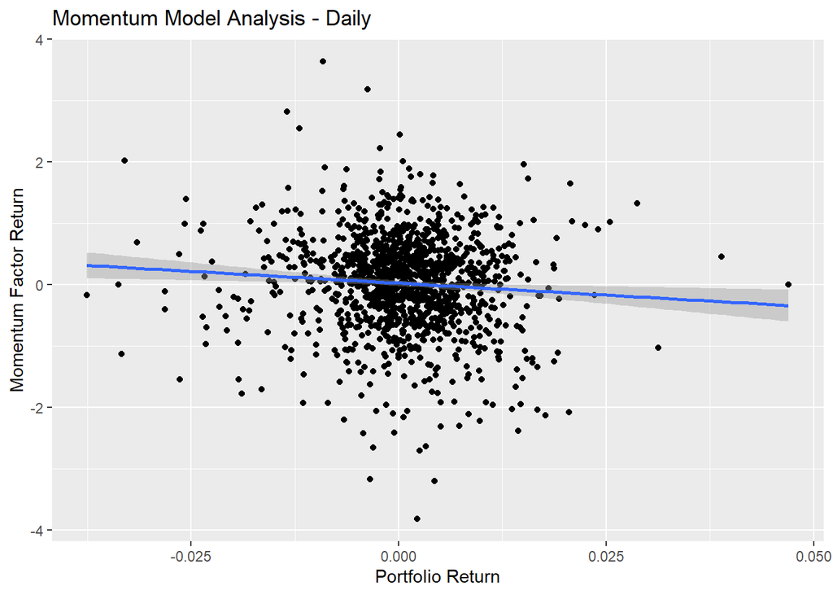

```r
ggplot(factormodel, aes(tret2,MOM))+ geom_point() + labs(title = "Momentum Model Analysis - Daily") + labs(x="Portfolio Return", y="Momentum Factor Return") + geom_smooth(method='lm', formula= y~x)
```

Adding the Momentum Factor to the Fama French model, we obtain the Momentum 4 factor model. Momentum is the return obtained by investing in stocks that perform well as part of momentum trading (Once a stock goes up, it will keep going up for the next cluster of trading session while similarly once it starts going down it will keep going down). We once again observe a marginal increase in both R^2: 0.8965 and adjusted R^2: 0.8961 (this is corroborated by the graph which is showing a mild linear relationship) suggesting that the Momentum Model is the best way so far to forecast the return of our portfolio. Looking at all the coefficients, we observe once again that the Market coefficient contributes the most to the return of our portfolio, followed by Value and Momentum. We also notice that Size on average detracts from the total return of our portfolio; thus we conclude that we should not invest too heavily into smaller companies.

## Chapter VII: Monte Carlo Simulations & Forecasting

As part of the Monte Carlo Forecasting, we aim to predict & visualize the value of individual stocks as well as the overall portfolio. The maths behind the simulation are fairly interesting and involve several parts.

1. We will use the existing return data to observe the annualized average return and annualized standard deviation for each stock while also computing the correlation matrix for our individual returns.
2. The correlation matrix will be decomposed using the Cholesky Decomposition into the Lower and Upper Matrices. At the same time, we will generate 1000 standard normal random variables which we incorporate into the Lower Matrix in order to impose the same historical correlation into our forecast.
3. Next we will compute 1000 paths/ prices for each stock in the portfolio using the geometric Brownian Motion formula for stock prices which incorporates the average returns, volatilities and correlation for our portfolio of stocks.
4. In order to finally obtain our Monte Carlo forecast, we take the average of our forecasted price per stock and add 90 percent confidence intervals
5. Last, we will visualize our results and draw conclusions for our portfolio as well as compute the portfolio return based on our forecast as well as the portfolio return after we apply our stock selection technique.

```r
#monte carlo
return <- return[-(1:2),]
n = 1000
k <- c(1:(ncol(df)-1))
col <- c(1:n)
lower <- t(chol(cor(df[,2:19])))
rand_mat <- matrix(rnorm((ncol(df)-1)*n, mean = 0, sd = 1),nrow = ncol(df)-1,ncol = n)
rand <- data.frame(rand_mat)
NewCorr_mat <- matrix(0, nrow = ncol(df)-1, ncol = n)
NewCorr <- data.frame(NewCorr_mat)
ST_mat <- matrix(0, nrow = ncol(df)-1, ncol = n)
ST <- data.frame(ST_mat)
S0 <- df[1248, 2:19]
S0 <- t(S0)
Miu_mat <- colMeans(return)*253
Miu <- data.frame(Miu_mat)
Sigma_mat <- colSds(as.matrix(return, na.rm=TRUE))*sqrt(253)
Sigma <- data.frame(Sigma_mat)
Time = 5
for (i in k){
  for (j in col){
    sum = 0
    for (I in k){
      sum = sum + lower[i,I] * rand[I,j]
      NewCorr[i,j] = sum
    }
    ST[i,j] = S0[i,1]*exp(Miu[i,1] - (Sigma[i,1]^2)/2*Time + Sigma[i,1]*sqrt(Time)*NewCorr[i,j])

    }
  }
```

```r
Predict <- rowMeans(ST)
Predict <- data.frame(Predict)
Predict <- t(Predict)
predict_date <- as.Date("2024/11/01", "%Y/%m/%d")
predict_date <- data.frame(predict_date)
Predict <- cbind(predict_date, Predict)
colnames(Predict) <- c('Date','AMZN',   'BAC',  'CAT',  'COST', 'DIS',  'GOOG', 'GS',   'IBM',  'JNJ',  'MRK',  'MS',   'MSFT', 'PFE',  'TGT',  'WMT','ZTO', 'LN', 'RACE')
```

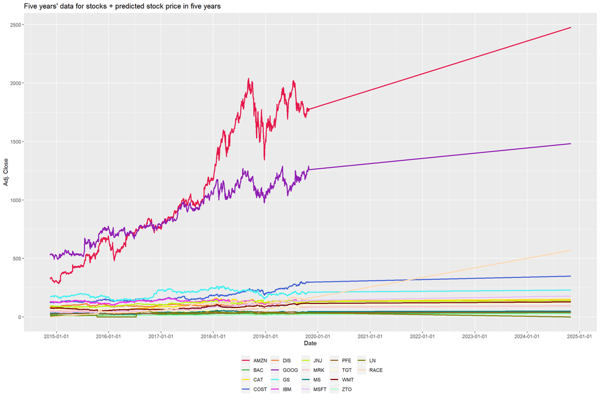

```r
df_predict <- rbind(df,Predict)

meltdf <- melt(df_predict,id="Date")

ggplot(meltdf, aes(Date, y=value,colour=variable,group=variable)) +
  geom_line(size=1) +
  labs(title="Five years' data for stocks + predicted stock price in five years", x="Date", y="Adj. Close") +
  theme(legend.position="bottom") +
  theme(legend.title=element_blank()) +
  scale_x_date(breaks = "1 year") +
  scale_color_manual(values=palette)
```

In order to diversify our portfolio, we need to add/ keep other stocks as well in order to hedge against downside risk. Let’s have a look at our forecasts after we scaled based on initial value to make comparison between all stocks:

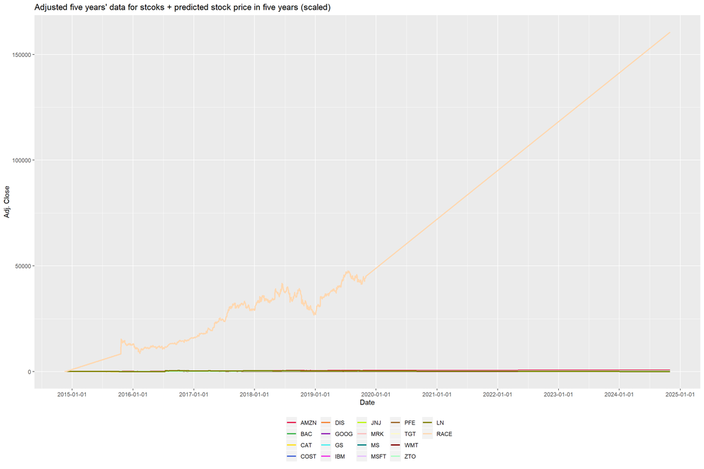

```r
df_predict <- rbind(df,Predict)


dfa_predict <- lapply(select(df_predict, -Date), function(x) 100*x/x[1])
dfa_predict <- cbind(Date = df_predict$Date, as.data.frame(dfa_predict))
dfam_predict <- melt(dfa_predict, id="Date", variable.name="share",value.name="price")


ggplot(dfam_predict, aes(Date, y=price, colour=share, group=share)) +
  geom_line(size=1) +
  labs(title="Adjusted five years' data for stcoks + predicted stock price in five years (scaled)", x="Date", y="Adj. Close") +
  theme(legend.position="bottom") +
  theme(legend.title=element_blank()) +
  scale_x_date(breaks = "1 year")+
  scale_color_manual(values=palette)
```

RACE seems to have an accelarating growth and prevents us from observing the portfolio as a whole. To see clearly what the remaining predictions are, we plot another graph without `RACE` and zoom in to observe.

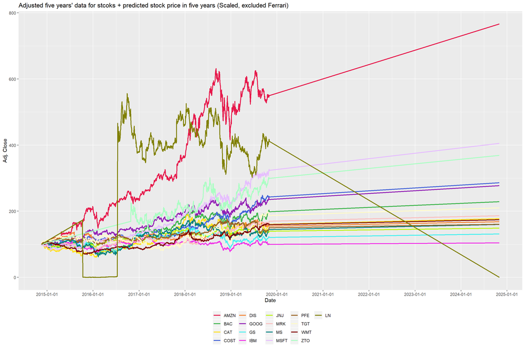

```r
df_predict <- rbind(df,Predict)


dfa_predict <- lapply(select(df_predict, -Date), function(x) 100*x/x[1])
dfa_predict <- cbind(Date = df_predict$Date, as.data.frame(dfa_predict))
dfam_predict <- melt(dfa_predict, id="Date", variable.name="share",value.name="price")
dfam_scaled_predict <- subset(dfam_predict,share!="RACE")


ggplot(dfam_scaled_predict, aes(Date, y=price, colour=share, group=share)) +
  geom_line(size=1) +
  labs(title="Adjusted five years' data for stcoks + predicted stock price in five years (Scaled, excluded Ferrari)", x="Date", y="Adj. Close") +
  theme(legend.position="bottom") +
  theme(legend.title=element_blank()) +
  scale_x_date(breaks = "1 year")+
  scale_color_manual(values=palette[-18])
```

The first observation is that the predicted price for LN(LINE Corporation) is zero. This might be due to the fact that the stock was not traded for a short period of time. We choose to exclude Line from our final portfolio. It seems that our attempt to forecast the missing values through linear regression did not go so well since two out of the three stocks with missing values filled have abnormal behavior. We may conclude that we need a more complicated regression model to do the job or simply skip the imputation. We choose to remove these stocks from the portfolio (RACE, LN) Once again, we will keep AMZN (Amazon) and Google as they have positive slopes that increase fast (In general, we would like to keep all stocks with positive slope).

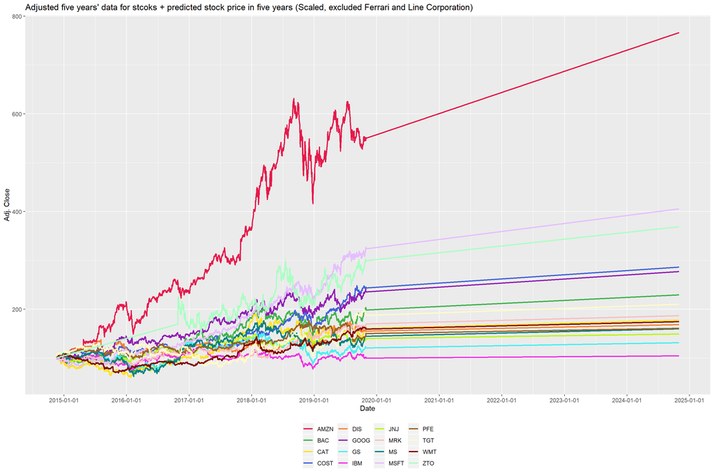

```r
dfam_scaled_final <- subset(dfam_scaled_predict,share!="LN")

ggplot(dfam_scaled_final, aes(Date, y=price, colour=share, group=share)) +
  geom_line(size=1) +
  labs(title="Adjusted five years' data for stcoks + predicted stock price in five years (Scaled, excluded Ferrari and Line Corporation)", x="Date", y="Adj. Close") +
  theme(legend.position="bottom") +
  theme(legend.title=element_blank()) +
  scale_x_date(breaks = "1 year")+
  scale_color_manual(values=palette[-c(17,18)])
```

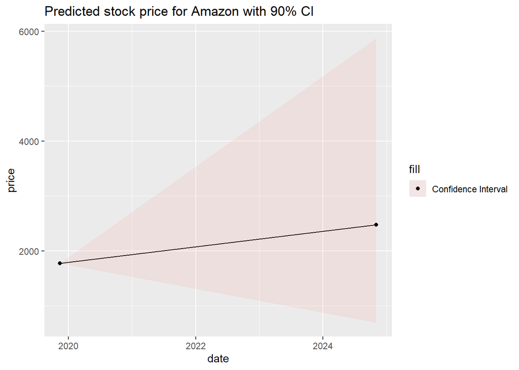

```r
start_date <- as.Date("2019/11/15", "%Y/%m/%d")
predict_date <- as.Date("2024/11/01", "%Y/%m/%d")


AMZN <- t(ST[1,])
AMZN <- sort(AMZN)
AMZN <- data.frame(AMZN)
colnames(AMZN) = 'AMZN'
CI_lower <- AMZN[50,1]
CI_upper <- AMZN[950,1]

date <-c(start_date, predict_date)
date <- data.frame(date)
company <- c('AMZN', 'AMZN')
company <- data.frame(company)
price <- c(df[1248, 2], Predict[1,2])
price <- data.frame(price)
lower <- c(df[1248, 2], CI_lower)
lower <- data.frame(lower)
upper <- c(df[1248,2], CI_upper)
upper <- data.frame(upper)
data <- cbind(date, company, price, lower, upper)

p<-ggplot(data, aes(x=date, y=price, fill='Confidence Interval')) +
  geom_point() +
  geom_line() +
  geom_ribbon(aes(ymin=data$lower, ymax=data$upper), linetype=2, alpha=0.1) +
  ggtitle('Predicted stock price for Amazon with 90% CI')

p
```

We also want to be mindful of the confidence intervals for our predictions as worse outcomes may occur given a bear market (our analysis was conducted during a bull market hence the inflated returns. Looking at the 90% confidence interval for Amazon we observe quite a bit of upside potential (AMZN may go up to $6000 assuming above average growth) while the worst possible scenarios would see the stock go down below $1000.

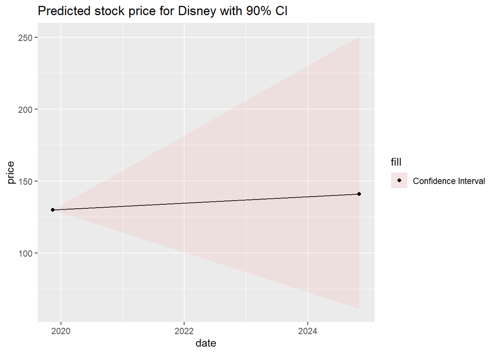

```r
DIS <- t(ST[5,])
DIS <- sort(DIS)
DIS <- data.frame(DIS)
colnames(DIS) = 'DIS'
CI_lower <- DIS[50,1]
CI_upper <- DIS[950,1]


company <- c('DIS', 'DIS')
price <- c(df[1248, 6], Predict[1,6])
lower <- c(df[1248, 6], CI_lower)
upper <- c(df[1248,6], CI_upper)
data <- cbind(date, company, price, lower, upper)

p<-ggplot(data, aes(x=date, y=price, fill='Confidence Interval')) +
  geom_point() +
  geom_line() +
  geom_ribbon(aes(ymin=data$lower, ymax=data$upper), linetype=2, alpha=0.1) +
  ggtitle('Predicted stock price for Disney with 90% CI')

p
```

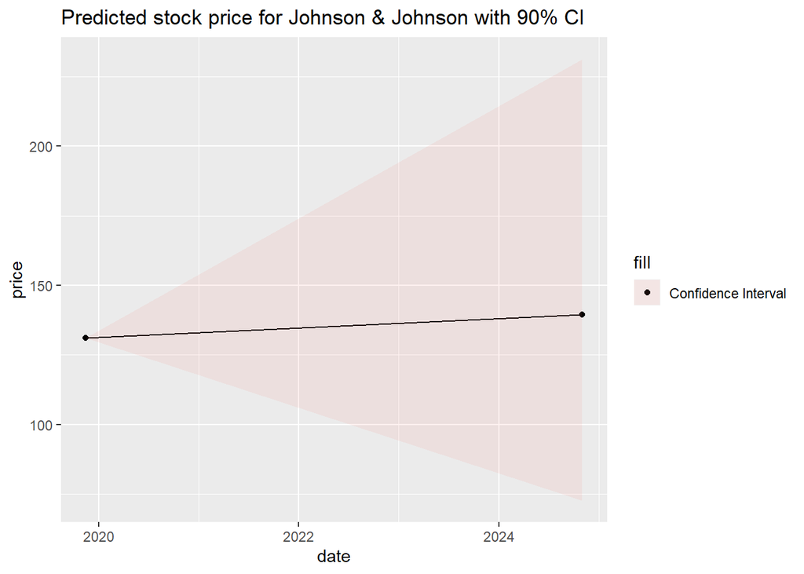

```r
JNJ <- t(ST[9,])
JNJ <- sort(JNJ)
JNJ <- data.frame(JNJ)
colnames(JNJ) = 'JNJ'
CI_lower <- JNJ[50,1]
CI_upper <- JNJ[950,1]


company <- c('JNJ', 'JNJ')
price <- c(df[1248, 10], Predict[1,10])
lower <- c(df[1248, 10], CI_lower)
upper <- c(df[1248,10], CI_upper)
data <- cbind(date, company, price, lower, upper)

p<-ggplot(data, aes(x=date, y=price, fill='Confidence Interval')) +
  geom_point() +
  geom_line() +
  geom_ribbon(aes(ymin=data$lower, ymax=data$upper), linetype=2, alpha=0.1) +
  ggtitle('Predicted stock price for Johnson & Johnson with 90% CI')

p
```

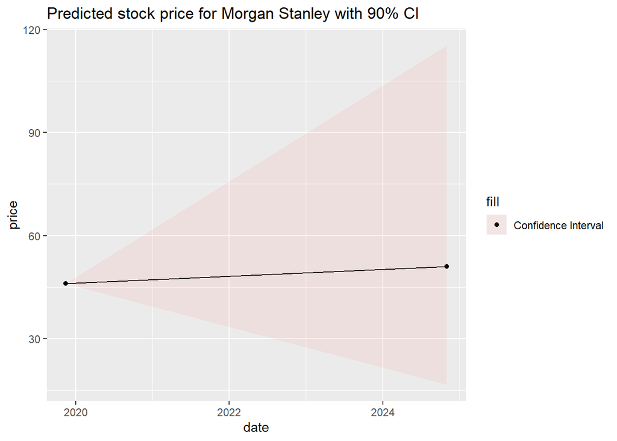

```r
MS <- t(ST[11,])
MS <- sort(MS)
MS <- data.frame(MS)
colnames(MS) = 'MS'
CI_lower <- MS[50,1]
CI_upper <- MS[950,1]


company <- c('MS', 'MS')
price <- c(df[1248, 12], Predict[1,12])
lower <- c(df[1248, 12], CI_lower)
upper <- c(df[1248, 12], CI_upper)
data <- cbind(date, company, price, lower, upper)

p<-ggplot(data, aes(x=date, y=price, fill='Confidence Interval')) +
  geom_point() +
  geom_line() +
  geom_ribbon(aes(ymin=data$lower, ymax=data$upper), linetype=2, alpha=0.1) +
  ggtitle('Predicted stock price for Morgan Stanley with 90% CI')

p
```

Morgan Stanley is projected to have a steady growth with an average predicted 5 year price of $50. Best case scenarios would see the stock fly up to $120 while worst case scenarios would see the stock go down to around $20.

## Chapter VIII: Interactive Graphs

### Part 1: D3- Stock price analysis

We visualized four stock prices(Morgan Stanley, Amazon, JNJ, Disney) based on data from Yahoo Finance. Features of the D3 Graph:

1. When clicking on the line, the price data on that respective date will be highlighted in several ways: blue line(amazon), green line(JNJ and Morgan Stanley), light blue line(Disney) are indicating stock price; The red line in all four graphs is indicating the average price, while the histogram on the bottom is indicating trading volume.
2. The date and numerical description of the data will be displayed on the top-left corner of the plot. Users can select zoom-in range of the data based on different time periods by clicking the buttons: one week(1w), one month(1m), three months(3m), six months(6m), one year(1y), five years(5y).
3. The box below the graph can be moved along the total time series in order to switch the zoom-in region, so that different periods of data can be selected.

**Johnson&Johnson(2014-2019)**

http://bl.ocks.org/yil479/a962d9785e42ea54aa2edf6a4dbf0ddf/28a78c1124bddec879b07195a0969bbbc13fcbd6

**Disney(2014-2019)**

http://bl.ocks.org/yil479/1ba241943d1fe1db71921adea7ff9d2e/cca58453ee6044a3a76d138585fb4c3e28525a36

**Morgan Stanley(2014-2019)**

http://bl.ocks.org/yil479/9014305de696c2392ddd4e78488fdc38/947770a2019c5628d208a670281d1b30bab55b6e

**Amazon(2014-2019)**

http://bl.ocks.org/yil479/9053e30eb305017afbbd0cde19a547c4/802157dc4471151c6156391b124ba0f5400e798d

Github link: https://github.com/yil479/Edav_finalproject2019/tree/master/Interactive_part/D3

### Part 2: Shiny app – stock return portofolio

https://yil479.shinyapps.io/123123/

This is a shiny app tool for visualizing and analyzing Yahoo finance stock market data. The main goal of this application is to build a U.S. stock market portfolio for investment decision making. We used a classic model, CAPM to help us generate the expected return given the input risk rate. We chose 15 stocks from four fields(technology, finance, entertainment, medical) as our target stocks to predict their returns Users can change the parameters based on their preference such as investment period(by clicking on 1m, 6m, 1y button or input date manually).

1. Users can also change their risk free rate to get different alpha results.
2. The graph will show the security market line to indicate overvalued stocks(low SML) and undervalued stocks(high SML).
3. The stock table will also indicate overvalued stocks(red) and undervalued stocks(green).

The Stock Table will show the following items:

1. Ticker Name
2. Beta - Correlation of the respect asset to the market.
3. Expected return and True return.
4. Alpha - a measurement used to determine how well a portfolio performs representing the skill of the portfolio manager/ stock picker.
5. R^2 - the coefficient of determination signaling how well the model performs.
6. Sortino Ratio - the risk-adjusted return of an asset by calculating the average return earned in excess of the risk-free rate per unit of volatility.

Once parameters are changed the app will automatically reload the real time stock data and perform an analysis automatically based on the new data.

Githublink: https://github.com/yil479/Edav_finalproject2019/tree/master/Interactive_part/shinnyapp

Reference: https://github.com/lamres/capm_shiny

## Chapter IX: Conclusion

```r
weight3 = 0.25
weight4 = 0.1

fprice <- rbind(df,Predict)
fprice <- fprice[-1:(-1247),1:ncol(fprice)]

freturn<- (fprice[2,]-fprice[1,])/fprice[1,]
freturn<-freturn[,-1]
#freturn <- data.frame(freturn)

tret3 <- rowSums(freturn*weight)
tret3 <- data.frame(tret3)
PortfolioRet2 <- prod(tret3+1)

PortfolioRet3 <- 1+(freturn$AMZN * weight3 + freturn$GOOG * weight3 +freturn$COST * weight4 +freturn$MS * weight4 +freturn$MSFT * weight4 +freturn$JNJ * weight4 +freturn$COST * weight4)

cat("\nIf we compute the value of the Portfolio for all the stocks on their predicted price we observe the Total Portfolio Return at ",(PortfolioRet2-1)*100,"%, while if we use our selection only based on our analysis, we observe that the portfolio return increases to ",(PortfolioRet3-1)*100,"%, which represents a total increase of ",((PortfolioRet3-1)-(PortfolioRet2-1))*100 ,"%")
```

[output not shown]

Please do note that our forecasts are based on historical data which was applied on normal random variables in order to compute our portfolio returns. In a scenario in which correlations between our stocks are significantly different (such a stock market crash when correlation invert and stick to each other) the predicted returns might be very different. In conclusion, we do believe that our portfolio will outperform the S&P500 given most market conditions as demonstrated thorugh several forecasts and analyses throught the project.